# We rate dogs twitter analysis report

The twitter project was to analyse tweets from @weratedogs twitter account from 2015 to 2017 august.

The project was done using python programming language.

The dataset were gathered from three different sources.we were provided the first dataset, the second was programatically downloaded using the request library.the third dataset was gotten using the tweepy library from twitter api.

The data has gone through the followeing steps:

- gathering
- accessing
- wrangling
- storing
- visualization

  The next step is the reporting :

### INSIGHTS

1. The bar chart below shows that most site visitors engaged @WeRateDogs using their iphones

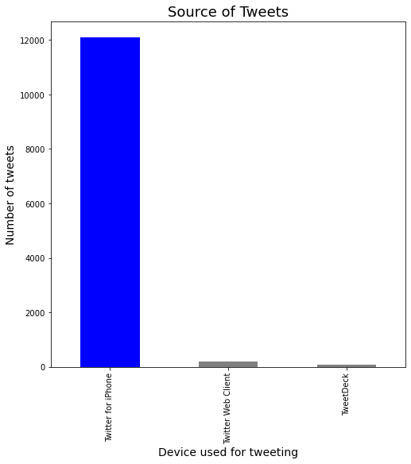

1. The most retweets were gotten by visitors using the twitter web client. this shows that visitors using the twitter web client are more likely to retweets . @WerateDogs should target visitors using the twitter web client to get more retweets.but it is worthy to note that there are other factors that could be at play such as contents of the tweet, the dog_stage as well

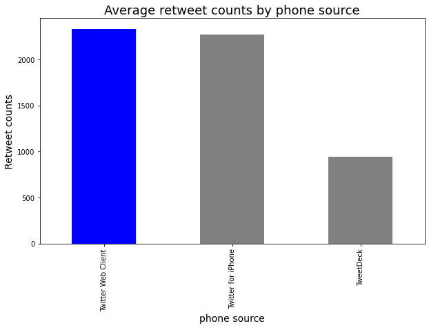

1. The most favorite counts were gotten by visitors using the twitter for iphone. this shows that visitors using the twitter for iphone are more likely to give more favourite counts . @WerateDogs should target visitors using the twitter for iphone to get more favourite counts.but it is worthy to note that there are other factors that could be at play such as contents of the tweet, the dog_stage as well

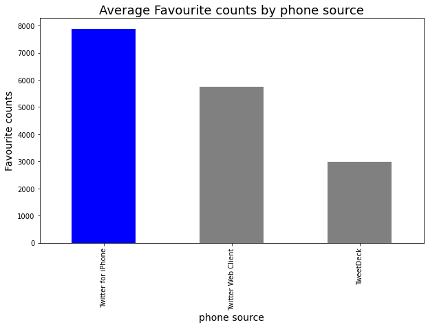

1. The scatter plot below shows that there is a positive relationship/correlation between retweets and Likes. As any tweet, Tweeted by WeRateDogs gets retweeted, there is a likely increase in number of Likes. Note that this correlation does not imply causability.

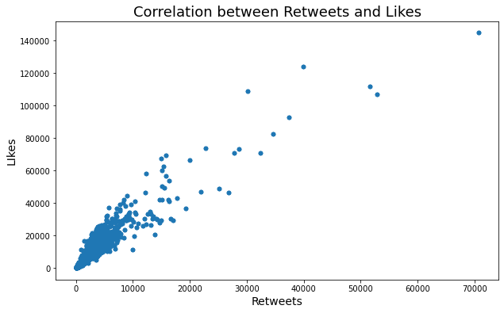

### Limitations to my analysis

1. Based on cleaning tweets that did not have a dog name, a particular source 'Vine' was eliminated. so the analysis is representative of only a short sample.
2. I could only infer correlation and not causation between retweets and likes